# Systematic comparison of our methods — review draft

Generated review copy: figures inlined, citations linked to the reference list

# Systematic comparison of our methods

## Scope of the comparison and modeling approaches

Global ship emission estimates fall into two methodological families, distinguished by whether emissions are derived from aggregate statistics or from the activity of individual vessels. Top-down, fuel-based inventories combine reported marine fuel sales with fuel emission factors, without reference to individual ships. Such estimates rest on fleet-average parameters, cannot resolve operational behaviour, and are known to underestimate emissions relative to activity-based inventories (Miola and Ciuffo 2011). Bottom-up, activity-based approaches instead derive emissions mechanistically from the observed movement of individual vessels, calculating the pollutants emitted by each ship in a specific spatial context and aggregating over time and fleet (Nunes et al. 2017). Since the widespread adoption of AIS, which resolves ship activity and operational mode at high spatial and temporal resolution, bottom-up AIS-based models have become the reference methodology for global inventories and the approach adopted by the IMO (Faber et al. 2020). We therefore restrict our methods comparison to this family, which includes our AIS-based model, and retain top-down estimates only as an external check on global totals.

Any AIS-based inventory is assembled from four components, and the differences between published inventories are attributable to how each is specified. First, the AIS record itself, which determines which vessels and which movements are observed at all. Second, a vessel-characteristics dataset supplying the parameters the model requires. Third, an engine model converting observed speed into instantaneous main engine load, plus assumptions on auxiliary engine and boiler demand. Fourth, fuel consumption and pollutant specific emission factors, conditioned on engine type, fuel type and the regulation in force at the time and place of the emission. Supplementary Tables 1, 2 and 3 compare our methods, input data and outputs against the most recent and representative global bottom-up inventories: the STEAM model (Jalkanen et al. 2009, 2012; Berg et al. 2012; Johansson et al. 2017; Majamäki et al. 2025), SEIM (Wang et al. 2021; Yi et al. 2025), MariTEAM (Kramel et al. 2021), the OECD’s recent update transitioning from a machine-learning to a bottom-up approach (Clarke et al. 2023; OECD 2025), the SAVE model developed by the ICCT (Olmer et al. 2017; Mao et al. 2025b; Mao et al. 2025a), and the Fourth IMO GHG Study (Faber et al. 2020).

## Activity and vessel-characteristics data

All seven inventories in the supplementary tables are global in spatial extent, so the differences lie in AIS coverage, fleet size, and temporal continuity rather than in geographic scope (Supplementary Table 2). The inventories diverge substantially in the number of vessels represented. Restricting the comparison to vessels explicitly modelled from observed AIS activity, we model 864,738 unique vessels, an average of 396,221 vessels per year rising from 249,732 in 2015 to 529,848 in 2025. This exceeds the AIS modelled fleet of the Fourth IMO GHG Study, the OECD update, SAVE, MariTEAM and SEIM. Our fleet size is only comparable to the STEAM inventory, which reported 376,219 vessels in 2015, exceeding our fleet size for the same year. However, STEAM does not report fleet sizes in subsequent updates, preventing a direct comparison for the later years in which our fleet is larger. The difference with STEAM is also reflected in the underlying AIS data, which used approximately 7.8 billion AIS positions in 2015, compared with approximately 2.3 billion in our 2015 dataset after data cleaning. Our own message volume increases to approximately 26.5 billion positions by 2025, totaling approximately 125 billion positions over the study period (an average of 11.4 billion per year), reflecting the expansion of terrestrial and satellite AIS. It also reflects differences in the AIS data types available to us. Terrestrial and satellite AIS constitute the core AIS data types. In addition, GFW obtains a data add-on for both class A and class B Dynamic-AIS, released by the data provider Spire in 2022, which further increases the density and coverage of our AIS record. To our knowledge, D-AIS is generally not included in base AIS data products from most providers. However, we note that other inventories covering from 2022 onward report conventional AIS data types without explicitly indicating whether Dynamic-AIS (also marketed as shipborne AIS) is included. Therefore, we cannot determine whether the differences arise from variations in input data or simply from a lack of reporting. Among the remaining inventories, SEIM and MariTEAM report lower AIS message volumes, whereas the remaining do not indicate message counts.

Temporal coverage differs in extent. STEAM and MariTEAM are single-year inventories (2015 and 2017 respectively), with STEAM subsequently updated through 2021 to account for ambient conditions (Majamäki et al. 2025). SEIM covers 2013 and 2016-2021, the Fourth IMO GHG Study 2012-2018, SAVE 2016-2023, and the OECD from 2019 onward. Our use of consistent GFW AIS products, though input density evolves, enables a continuous AIS inventory from 2015—and AIS + S1 inventory from 2017—to the present without methodological discontinuities.

Every inventory uses official registries as the primary source of vessel characteristics and applies gap-filling where information is unavailable. The differences are in how far the registry is extended and how the remainder is inferred. The simplest filling approaches substitute central tendencies. The OECD update restricts to vessels matching between commercial and public registries and imputes from vessel class and size group means (OECD 2025), while SAVE fills missing characteristics from averages values (Mao et al. 2025b). STEAM retains some of the within class variation by replicating the characteristics of a similar vessel already listed in its database (Johansson et al. 2017). Regression-based approaches such as that used for MariTEAM, fills gaps using regression models, though its modelled fleet is fully restricted to the registered fleet (Kramel et al. 2021), while the Fourth IMO GHG Study applies similar regressions as its primary method and falls back to class and size medians, on a dataset expanded with registered and public datasets (Faber et al. 2020). Of the published inventories, SEIM is the only one besides ours to describe a more involved machine-learning approach to fill missing characteristics, applied after extending commercial registries with open data (Yi et al. 2025). In our vessel information dataset, characteristics are taken from data purchased from S&P Global, from publicly available official registries consolidated through extensive prior scraping work (Park et al. 2023), and where neither is available, from inferred characteristics, building on Kroodsma et al. (2018) using a new random-forest model trained on commercial registry data, enabling inclusion of a substantially larger number of vessels than most previous studies and reach a fleet dominated by small domestic and fishing vessels that the more registry-anchored inventories cannot represent.

## Engine and emissions model

In terms of propulsion formulation, the literature defines two main modeling approaches: load-based (i.e., SEIM, SAVE, the OECD update, the Fourth IMO GHG Study) and resistance-based (i.e., STEAM and MariTEAM). Every AIS-based inventory ultimately estimates the propulsion power required to overcome hull resistance at the observed speed, and the models differ in the resolution at which the components of that resistance are resolved. While load-based models are generally regarded as roughly representative of more complex methods, resistance-based models are often avoided because of the number of inputs needed. Resistance models require hull parameters, which restricts their applicability to vessels with such documented information in the registries. Imputing class-average hull parameters may be acceptable for fleet-level aggregates and well-defined classes with limited variation in hull design, but performance declines for underrepresented and heterogeneous classes and can substantially alter single-vessel estimates (Brown and Aldridge 2019). This limitation is particularly relevant because we model a broader fleet dominated by small domestic and fishing vessels, for which hull geometry is often absent or incomplete, and report emissions at a finer resolution, by trip and by vessel. The resistance model’s advantage in physical realism would therefore be offset by uncertainty in its inputs. The load-based formulation, by contrast, requires only installed power, design speed, observed speed and a small number of further characteristics that are readily available in registries and can be modeled with confidence where they are not.

In terms of other attributes, such as engine and fuel parameterization, we adapted the methods from the Fourth IMO GHG Study (Faber et al. 2020), which established standard assumptions now adopted by most of the shipping emissions models. Building an expanded activity dataset around a community reference also allows us to attribute differences from existing inventories to fleet coverage and activity representation, which is the claim this paper makes. Deviations from Faber et al. (2020) methods were dependent to data availability or the quality of inferred values, but remains in line with other load-based models (Yi et al. 2025; OECD 2025; Mao et al. 2025b). Correction factors for main engine activity are implemented, with draft corrections applied at a lower resolution than in Faber et al. (2020), Mao et al. (2025b) and OECD (2025), as draft is not reliably reported in our AIS records. Weather and fouling corrections follow comparable approaches to other load-based models, and an additional new correction is introduced to account for fishing activity. Similarly, SFOC calculations and decomposition in emissions by main auxiliary and boiler engines come from a general consensus across models (Faber et al. 2020; Yi et al. 2025; OECD 2025; Mao et al. 2025b), even among non load-based ones (Johansson et al. 2017; Kramel et al. 2021). See (Supplementary Table 1)

However, our approach is limited on its fuel types characterization which are not explicitly modeled due to lack of available vessel-level fuel type data. For a given engine type, SFOC values and emissions factors are therefore calculated as the average value from across the fuel types associated with each engine type. LNG was not included as a fuel type due to the lack of available vessel-level fuel type data, the very limited number of vessels that currently use LNG, and the vastly different emissions factors this fuel type produces. Our treatment of policy instruments is also narrower than that of comparable models, which apply fuel-sulphur and NOx limits geographically within Emission Control Areas (Johansson et al. 2017; Yi et al. 2025; Faber et al. 2020; Mao et al. 2025b). Additionally, STEAM and SAVE account for technologies such as scrubbers and dual-fuel operation. While our NOx limits are assigned by engine Tier from build year, these are not resolved by NOx ECA boundaries, and SOx and PM estimates are expected to be biased upward within ECAs, an effect concentrated before 2020, when the difference between ECA and global sulphur limits was largest.

## Differences in validation

Validation of existing inventories has rested largely on aggregate benchmarking against independent statistics, top-down approaches and against other bottom-up inventories. Our global totals were cross-compared against all six inventories discussed here, and against the multisector EDGAR and CEDS inventories (Guizzardi et al. 2025; Hoesly et al. 2018). As for the other models, STEAM benchmarked global fuel use against IEA statistics and the Third IMO GHG Study, modelled maritime transport work against UNCTAD seaborne-trade statistics and regional results against the EMEP inventory. SEIM, which rests entirely on this class of evidence, compares global totals and trends against EDGAR, CEDS and the Fourth IMO GHG Study, with an activity and fleet benchmark against UNCTAD. MariTEAM cross-compares against the Fourth IMO GHG Study for the same year and STEAM3 for a different year. The OECD update is the most extensive in this respect, benchmarking global totals against IEA and the Fourth IMO GHG Study, fleet activity against UNCTAD, average efficiencies by class and size against IMO (2018), and country-level results against national Air Emission Accounts for more than 35 countries. SAVE benchmarks aggregated fuel consumption against IMO DCS for ships of 5,000 GT and above, and the Fourth IMO GHG Study against the Third IMO GHG Study, their own top-down estimates, the ICCT inventory, and global fuel sales reported by the IEA and UNSD.

We also validate against two independent in situ measurement datasets: ship-specific measured fuel consumption for 15,679 unique vessels from a registered dataset, and EU MRV records covering 20,432 vessel-years. Together these constitute the largest ship-level validation sample reported for a global bottom-up shipping inventory. Other validations using in situ measurements include that of the Fourth IMO GHG Study, which compares yearly estimates against 9,739 vessel records in the 2018 EU MRV dataset and additionally draws on engine power and fuel consumption measurements from 94 vessels’ Continuous Monitoring Dataset (Faber et al. 2020). SAVE also validates per-vessel-year carbon intensity against EU MRV (Mao et al. 2025b). The OECD update likewise draws on EU MRV, but compares totals aggregated by vessel class rather than by individual vessel (OECD 2025). MariTEAM validates modelled engine power against in situ measurements for a single vessel (Kramel et al. 2021). STEAM was validated in earlier versions against a limited sample of in situ measurements (Berg et al. 2012), and its recent ambient-conditions update validates modelled fuel consumption against 6,445 vessel-years records in the EU MRV data (Majamäki et al. 2025). This last comparison bears directly on the choice of propulsion formulation. Applied to an identical fleet and AIS record, resistance-based methods have been reported to yield lower fleet-level CO₂ than their load-based equivalents (Brown and Aldridge 2019), but that offset has so far been established only between models, or against limited samples of in situ measurements (Berg et al. 2012; Kramel et al. 2021). Here the two families, represented by STEAM and our model, are each tested against the same independent benchmark dataset (i.e., EU MRV) and perform comparably, both achieving an *R*<sup>2</sup> of approximately 0.8 (Majamäki et al. 2025), supporting our methodological choices and indicating that the load-based formulation as implemented here does not exhibit the systematic upward bias reported by Brown and Aldridge (2019).

# Comparing our emission estimates to other inventories

## Comparing our estimates with other bottom-up inventories

Table 1 — inventory_comparison_all_sources.tex. Annual marine vessel CO<sub>2</sub> emissions (billions of metric tonnes) for our AIS-based and fused (AIS + S1) estimates and for the published bottom-up, activity-based inventories. A dash marks a year for which an inventory publishes no estimate.

| Year | GFW (AIS + S1) | GFW (AIS) | IMO | OECD | SAVE (ICCT) | STEAM | SEIM | MariTEAM |
| --- | --- | --- | --- | --- | --- | --- | --- | --- |
| 2017 | 1.107 | 0.824 | 1.064 | - | 0.839 | 0.864 | 0.900 | 0.943 |
| 2018 | 1.143 | 0.861 | 1.056 | - | 0.869 | 0.874 | 0.939 | - |
| 2019 | 1.174 | 0.884 | - | 0.889 | 0.867 | 0.904 | 0.884 | - |
| 2020 | 1.198 | 0.879 | - | 0.855 | 0.838 | 0.823 | 0.800 | - |
| 2021 | 1.270 | 0.941 | - | 0.894 | 0.864 | 0.879 | 0.825 | - |
| 2022 | 1.341 | 1.005 | - | 0.912 | 0.884 | - | - | - |
| 2023 | 1.377 | 1.054 | - | 0.920 | 0.890 | - | - | - |
| 2024 | 1.467 | 1.139 | - | 0.973 | - | - | - | - |
| 2025 | 1.533 | 1.189 | - | 0.986 | - | - | - | - |

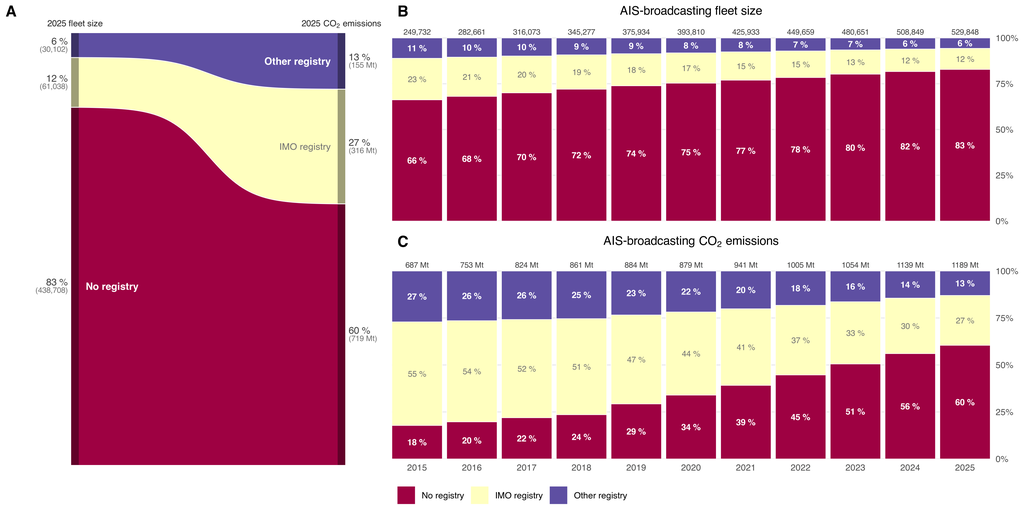

Figure 2 — figS-registry-sankey-with-series-2025-1.png

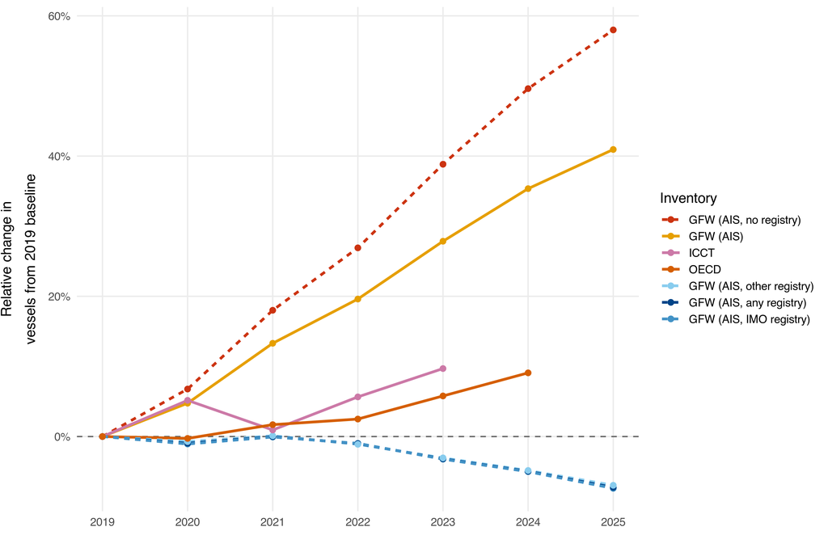

Figure 3 — figS-inventory-vessel-counts-by-registry-1.png

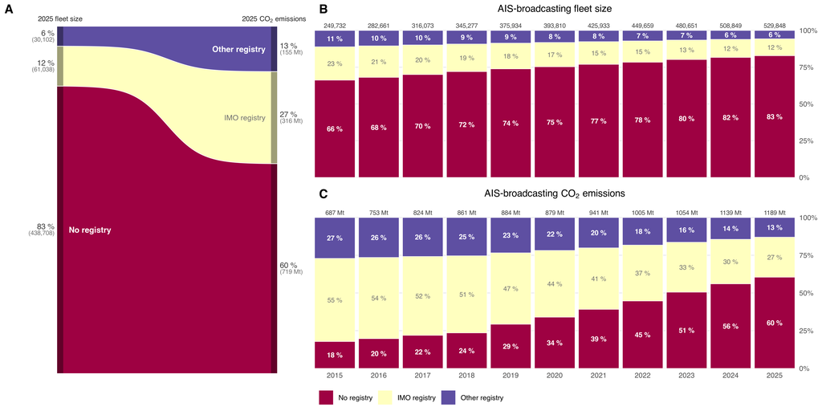

Figure 2 (shown again) — figS-registry-sankey-with-series-2025-1.png

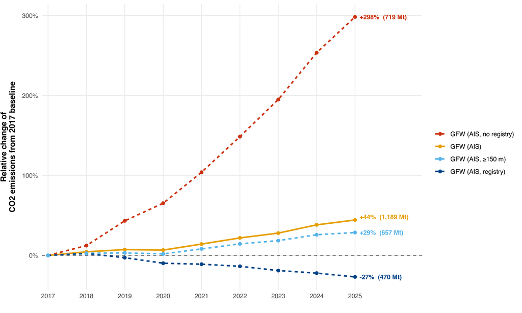

Figure 4 — figS-registry-split-comparison-1.png

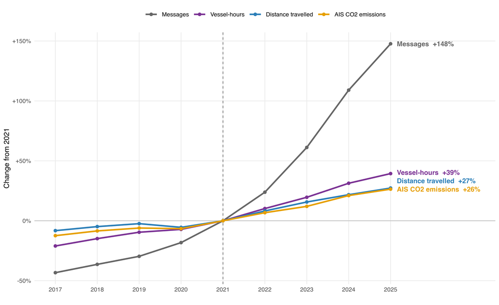

Figure 6 — figS-messages-vs-hours-vs-emissions-1.png

The above suggests that the increase in emissions occurs mostly via AIS carriage and, to a lesser extent, AIS coverage. The emissions divergence against the other inventories therefore does not indicate that our totals are inflated—a conclusion also supported by our global per-vessel emissions and emission intensities relative to other models (inventory_intensity_all_models.tex)—but rather that the other inventories, and our own early years, are missing part of the fleet and activity at sea. Global fleet emissions are likely understated wherever limited AIS carriage and/or high reliance on registry-defined fleets leaves low-information vessels out of the scope. This is supported by the S1 detection record where the share of detections that cannot be matched to an AIS broadcast has declined in all size classes since 2017, most steeply among fishing vessels and small non-fishing vessels, indicating an increase in AIS adoption (figS-unmatched-fraction-fullperiod-1.png). Indeed, the largest emissions growth we observe comes from passenger vessels, driven by the smallest group (figS-passenger-size-panels-1.png), and fishing vessels, a fleet segment comprising numerous small, largely coastal vessels that are poorly covered by registries and enter the model only as their AIS carriage expands (figS-fleet-growth-by-year-1.png and figS-fleet-sankey-with-series-2025-1.png). This is precisely the segment that registry-based methods are least equipped to capture.

Table 2 — inventory_intensity_all_models.tex. CO<sub>2</sub> intensity per vessel for each inventory in the comparison, ordered by intensity. Intensities are computed on the fleet count each model publishes: single-total models use their reported figure, per-year models the mean over years where both a count and emissions exist, and the GFW rows our own activity summary on the same basis. Per-distance intensity is shown only for the models reporting distance travelled: SAVE (ICCT) restricted to its distance-reporting classes, and our AIS series whole and registry-matched.

| Inventory | CO<sub>2</sub> per vessel (kt) | CO<sub>2</sub> per distance (kg nm<sup>-1</sup>) |
| --- | --- | --- |
| MariTEAM | 20.55 | — |
| SEIM | 7.90 | — |
| OECD | 7.83 | — |
| SAVE (ICCT distance-reporting classes) | 6.78 | 289.5 |
| GFW (AIS, any registry) | 6.08 | 317.8 |
| IMO | 4.92 | — |
| SAVE (ICCT) | 3.39 | — |
| GFW (AIS) | 2.34 | 322.4 |
| STEAM | 2.33 | — |

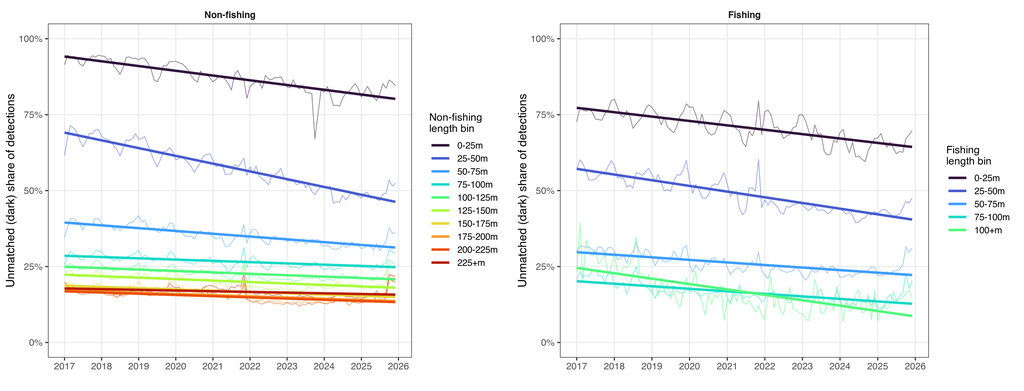

Figure 7 — figS-unmatched-fraction-fullperiod-1.png

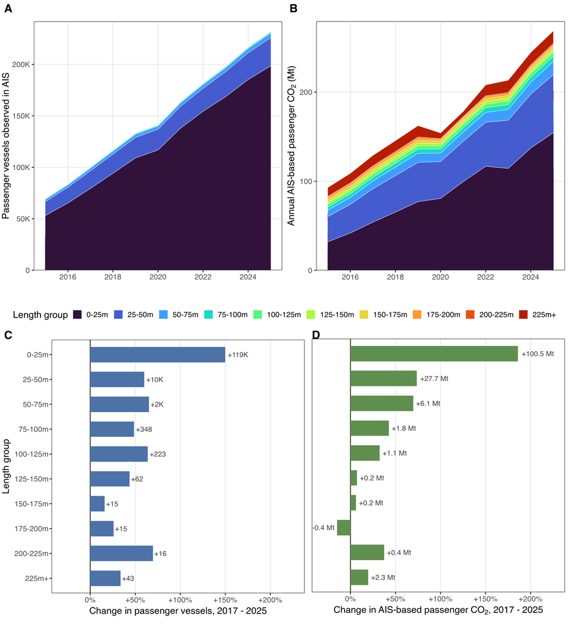

Figure 8 — figS-passenger-size-panels-1.png

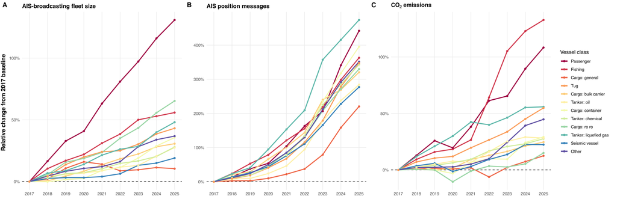

Figure 9 — figS-fleet-growth-by-year-1.png

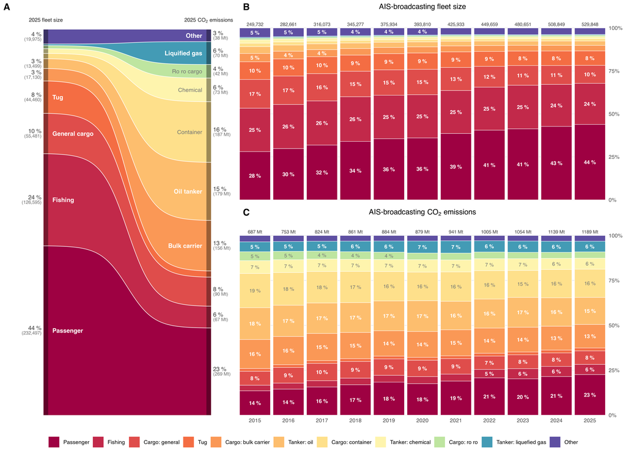

Figure 10 — figS-fleet-sankey-with-series-2025-1.png

## Comparing our estimates with top-down inventories

We also compared our total estimates against two top-down inventories, the Emissions Database for Global Atmospheric Research (EDGAR) and the Community Emissions Data System (CEDS). EDGAR builds its shipping estimates from reported fuel sales, representing international shipping from international marine bunkers and domestic activity from domestic navigation fuel statistics, with recent years extrapolated from Energy Institute fuel oil trends (Guizzardi et al. 2025). EDGAR can therefore only count fuel that was sold and reported. CEDS also starts from reported fuel sales but treats them as incomplete, on the view that marine fuel is systematically underreported, and raises its global shipping total using bottom-up estimates, mainly from the IMO GHG Studies (Hoesly et al. 2018; Joint Global Change Research Institute 2025). Its limits are therefore not only what gets sold, but also the coverage of the bottom-up studies its global total rests on, whose limitations were described in the previous section.

Our total estimates (summed across broadcasting and non-broadcasting vessels) exceed both inventories, each of which is bounded by the fleet and activity they can resolve (figS-multisector-shipping-comparison-1.png, tabulated in multisector_shipping_comparison.tex). The differences are in magnitude and in trend, reflecting differences in fleet scope and composition, respectively.

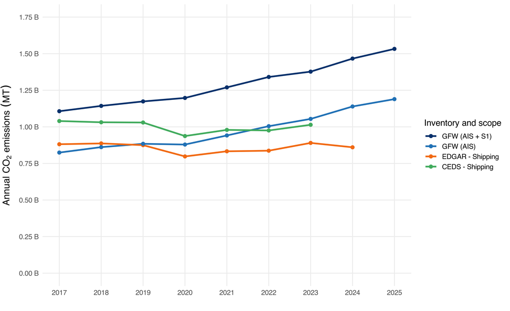

Figure 11 — figS-multisector-shipping-comparison-1.png

Table 3 — multisector_shipping_comparison.tex. Annual marine vessel CO<sub>2</sub> emissions (billions of metric tonnes) for our AIS-based and fused (AIS + S1) estimates against the shipping sector of the top-down EDGAR and CEDS inventories, whose shipping scope combines international and domestic navigation. A dash marks a year for which an inventory publishes no estimate.

| Year | GFW (AIS + S1) | GFW (AIS) | EDGAR - Shipping | CEDS - Shipping |
| --- | --- | --- | --- | --- |
| 2017 | 1.107 | 0.824 | 0.881 | 1.040 |
| 2018 | 1.143 | 0.861 | 0.887 | 1.031 |
| 2019 | 1.174 | 0.884 | 0.875 | 1.030 |
| 2020 | 1.198 | 0.879 | 0.798 | 0.937 |
| 2021 | 1.270 | 0.941 | 0.833 | 0.979 |
| 2022 | 1.341 | 1.005 | 0.837 | 0.975 |
| 2023 | 1.377 | 1.054 | 0.890 | 1.014 |
| 2024 | 1.467 | 1.139 | 0.860 | - |
| 2025 | 1.533 | 1.189 | - | - |

The magnitude gap arises from three main differences in the fleets these inventories can account for. First, fishing largely falls outside the shipping sector in both inventories. They report fishing fuel combined with agriculture and forestry, so EDGAR’s shipping estimates contain no fishing vessels at all, while in CEDS only some unreported fishing fuel is absorbed into its global shipping sector through the bottom-up anchor. Second, small coastal and inland vessels are only partly covered. Domestic navigation fuel is intended to capture this traffic, but the sector is known to be inconsistently defined across reporting countries, with emissions double-counted or omitted (Kuenen et al. 2014). Third, neither inventory can capture fuel that never passes through reported channels, affecting vessels supplied informally or illegally. Further, even when sales are reported correctly, bunker statistics change only as fast as national energy reporting is revised.

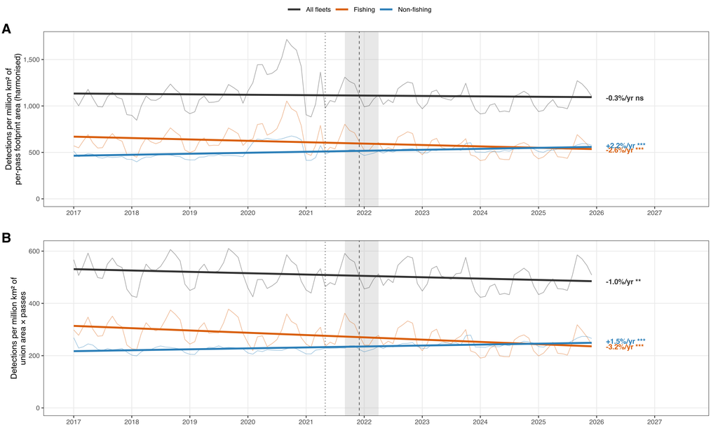

Figure 12 — figS-density-denominators-and-bins-1.png

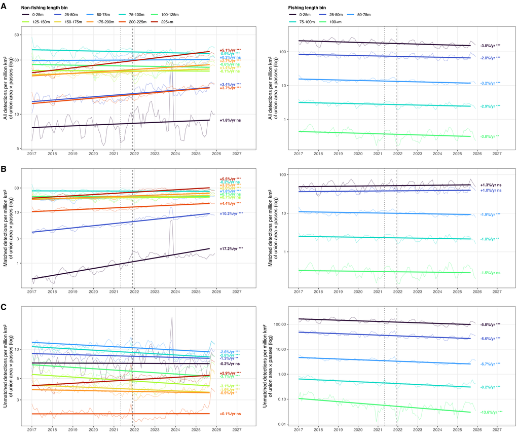

Figure 13 — figS-density-by-match-status-1.png

The magnitude gap rests on firm ground: each of these mechanisms adds emissions the top-down inventories cannot account for, and our own detection limits can only mean we understate the total further. However, for the trend, whether the increase in activity explains it depends on whether the increase reflects real activity rather than the limits of what our fused approach can observe.

Reallocation between our components requires that a vessel beginning to broadcast was already represented in the non-broadcasting estimate, and that holds only where Sentinel-1 detects it. Vessels too small or too close to shore to be reliably detected, or operating outside the imaged footprint—which accounts for a fifth of our AIS emissions—contribute nothing to that component and might enter the fused total for the first time when they begin broadcasting. Because AIS carriage and reception expanded over the study period, the unobserved fraction was larger at the start of the series than at the end, so part of the measured growth in the fused total is that gap closing rather than activity rising. Figure figS-density-by-match-status-1.png (panel B and C) shows that this might be the case. Among non-fishing vessels under 25 m, matched detections (i.e., AIS-broadcasting) per unit of observing effort rise at 17% per year while unmatched detections stay flat, so the growth there is added to the fused total rather than transferred within it. That addition could, in principle, reflect new vessels entering service. However, a 150% increase in passenger vessels under 25 m over eight years in our AIS record (figS-passenger-size-panels-1.png) is difficult to reconcile with the idea that new construction of small craft could plausibly account for it. The more likely interpretation is that most of these vessels were already at sea but unobserved by S1, and became visible as AIS carriage and reception expanded, representing activity newly entering our record rather than newly occurring. A fused trend closely tracking the AIS-only trend is consistent with this. That the fused slope is slightly shallower indicates some genuine reallocation from the non-broadcasting component, but the similarity between the two implies that some of the measured growth enters directly through AIS rather than being transferred within the fused total.

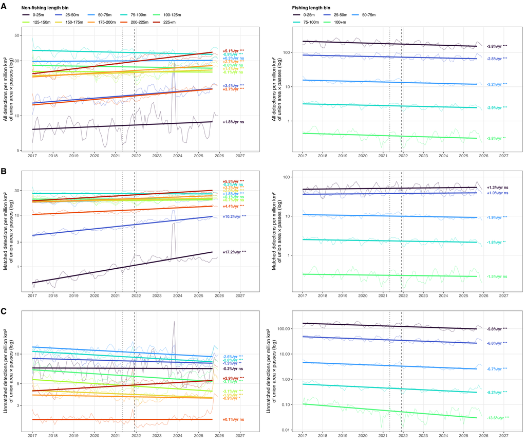

Figure 13 (shown again) — figS-density-by-match-status-1.png

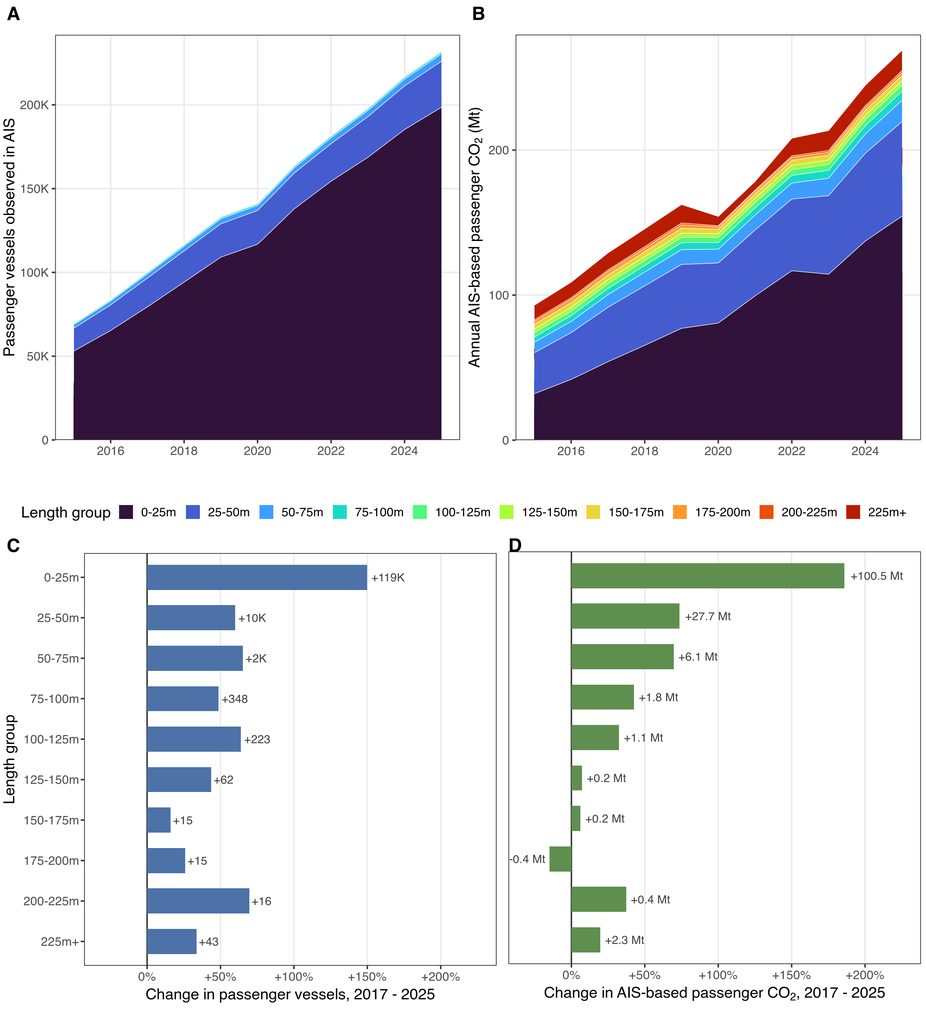

Figure 8 (shown again) — figS-passenger-size-panels-1.png

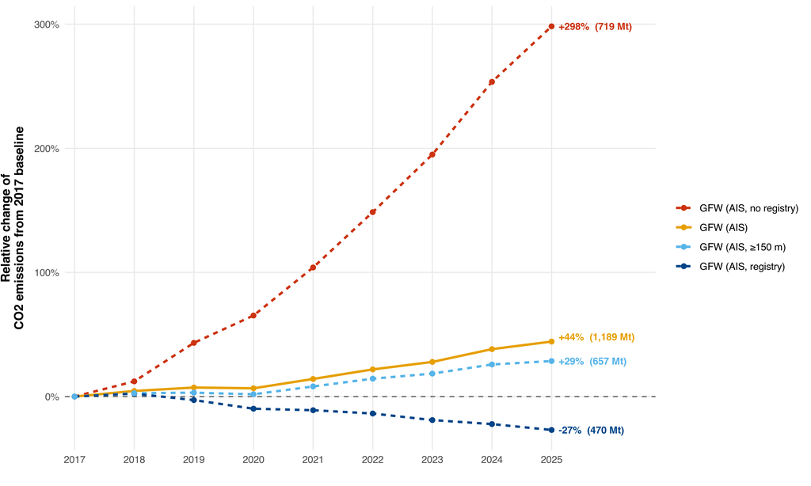

Figure 4 (shown again) — figS-registry-split-comparison-1.png

If these larger magnitudes and steeper trends were confirmed, the implication is not only that marine emissions have been systematically underreported, but that marine transport is among the fastest-growing sources in the global emissions picture. Our fused estimate grows roughly 4-5 times faster than global emissions across all sectors, and 7-10 times faster than all other transportation modes combined across EDGAR and CEDS (figS-multisector-comparison-1.png). Even confined to the segment of the fleet where observation capacity did not expand (i.e, non-fishing vessels of 150 m and above) the increase in AIS-based emissons remains more than 3 times that of global emissions across all sectors and more than 5 times that of all other transportation modes combined.

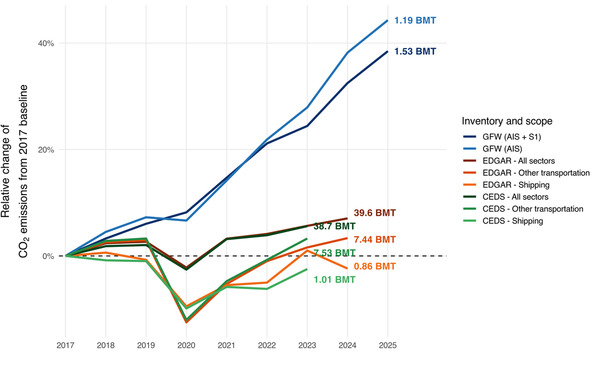

Figure 14 — figS-multisector-comparison-1.png

Berg, N., J. Mellqvist, J.-P. Jalkanen, and J. Balzani. 2012. “Ship Emissions of SO<sub>2</sub> and NO<sub>2</sub>: DOAS Measurements from Airborne Platforms.” *Atmospheric Measurement Techniques* 5 (5): 1085–98. https://doi.org/10.5194/amt-5-1085-2012.

Brown, Isabela N., and Michael F. Aldridge. 2019. “Power Models and Average Ship Parameter Effects on Marine Emissions Inventories.” *Journal of the Air & Waste Management Association* 69 (6): 752–63. https://doi.org/10.1080/10962247.2019.1580229.

Clarke, Daniel, Philip Chan, Matthew Dequeljoe, Yuri Kim, and Sarah Barahona. 2023. *CO2 Emissions from Global Shipping: A New Experimental Database*.

Faber, Jasper, Shinichi Hanayama, Shuang Zhang, et al. 2020. “Fourth International Maritime Organization Greenhouse Gas Study.” *London, UK*.

Guizzardi, Diego, William Becker, Federico Pagani, Marilena Muntean, and Monica Crippa. 2025. “Global up-to Date Emissions Using the EDGAR Fast-Track Methodology.” *Scientific Data* 12 (1): 1243. https://doi.org/10.1038/s41597-025-04806-2.

Hoesly, Rachel M., Steven J. Smith, Leyang Feng, et al. 2018. “Historical (1750–2014) Anthropogenic Emissions of Reactive Gases and Aerosols from the Community Emissions Data System (CEDS).” *Geoscientific Model Development* 11 (1): 369–408. https://doi.org/10.5194/gmd-11-369-2018.

Jalkanen, J.-P., A. Brink, J. Kalli, H. Pettersson, J. Kukkonen, and T. Stipa. 2009. “A Modelling System for the Exhaust Emissions of Marine Traffic and Its Application in the Baltic Sea Area.” *Atmospheric Chemistry and Physics* 9 (23): 9209–23. https://doi.org/10.5194/acp-9-9209-2009.

Jalkanen, J.-P., L. Johansson, J. Kukkonen, A. Brink, J. Kalli, and T. Stipa. 2012. “Extension of an Assessment Model of Ship Traffic Exhaust Emissions for Particulate Matter and Carbon Monoxide.” *Atmospheric Chemistry and Physics* 12 (5): 2641–59. https://doi.org/10.5194/acp-12-2641-2012.

Johansson, Lasse, Jukka-Pekka Jalkanen, and Jaakko Kukkonen. 2017. “Global Assessment of Shipping Emissions in 2015 on a High Spatial and Temporal Resolution.” *Atmospheric Environment* 167 (October): 403–15. https://doi.org/10.1016/j.atmosenv.2017.08.042.

Joint Global Change Research Institute. 2025. *CEDS Data and Assumptions Documentation*. [Https://github.com/JGCRI/CEDS/wiki/Data_and_Assumptions](https://github.com/JGCRI/CEDS/wiki/Data_and_Assumptions); GitHub Wiki.

Kramel, Diogo, Helene Muri, YoungRong Kim, et al. 2021. “Global Shipping Emissions from a Well-to-Wake Perspective: The MariTEAM Model.” *Environmental Science & Technology* 55 (22): 15040–50. https://doi.org/10.1021/acs.est.1c03937.

Kroodsma, David A., Juan Mayorga, Timothy Hochberg, et al. 2018. “Tracking the Global Footprint of Fisheries.” *Science* 359 (6378): 904–8.

Kuenen, J. J. P., A. J. H. Visschedijk, M. Jozwicka, and H. A. C. Denier van der Gon. 2014. “TNO-MACC_II Emission Inventory; a Multi-Year (2003–2009) Consistent High-Resolution European Emission Inventory for Air Quality Modelling.” *Atmospheric Chemistry and Physics* 14 (20): 10963–76. https://doi.org/10.5194/acp-14-10963-2014.

Majamäki, Elisa, Lasse Johansson, Tiia Grönholm, and Jukka-Pekka Jalkanen. 2025. “Improving the Global Prediction of Shipping Emissions by Modelling the Effects of Ambient Conditions.” *Science of the Total Environment* 997: 180126.

Mao, Xiaoli, Zhihang Meng, Bryan Comer, and Tom Decker. 2025a. “Greenhouse Gas Emissions and Air Pollution from Global Shipping, 2016–2023.” *The International Council on Clean Transportation*.

Mao, Xiaoli, Z. Meng, Liudmila Osipova, B. Comer, H. J. Cho, and E. Sturrup. 2025b. *Systematic Assessment of Vessel Emissions (SAVE) V2025.03.1 Documentation*. Version 2025.1. Computer software; International Council on Clean Transportation. https://theicct.github.io/SAVE-doc/versions/v2025.1/.

Miola, Apollonia, and Biagio Ciuffo. 2011. “Estimating Air Emissions from Ships: Meta-analysis of Modelling Approaches and Available Data Sources.” *Atmospheric Environment* 45 (13): 2242–51. https://doi.org/10.1016/j.atmosenv.2011.01.046.

Nunes, R. A. O., M. C. M. Alvim-Ferraz, F. G. Martins, and S. I. V. Sousa. 2017. “The Activity-Based Methodology to Assess Ship Emissions - A Review.” *Environmental Pollution* 231 (December): 87–103. https://doi.org/10.1016/j.envpol.2017.07.099.

OECD. 2025. *Maritime Transport CO2 Emissions Methodology Update*. Methodological note. Organisation for Economic Co-operation; Development. https://www.oecd.org/content/dam/oecd/en/data/methods/eea/OECD-maritime-transport-CO2-emissions-methodology.pdf.

Olmer, Naya, Bryan Comer, Biswajoy Roy, Xiaoli Mao, and Dan Rutherford. 2017. “Greenhouse Gas Emissions from Global Shipping, 2013–2015 Detailed Methodology.” *International Council on Clean Transportation: Washington, DC, USA*, 1–38.

Park, Jaeyoon, Jennifer Van Osdel, Joanna Turner, et al. 2023. “Tracking Elusive and Shifting Identities of the Global Fishing Fleet.” *Science Advances* 9 (3): eabp8200.

Wang, Xiaotong, Wen Yi, Zhaofeng Lv, et al. 2021. “Ship Emissions Around China Under Gradually Promoted Control Policies from 2016 to 2019.” *Atmospheric Chemistry and Physics* 21 (18): 13835–53. https://doi.org/10.5194/acp-21-13835-2021.

Yi, Wen, Xiaotong Wang, Tingkun He, et al. 2025. “The High-Resolution Global Shipping Emission Inventory by the Shipping Emission Inventory Model (SEIM).” *Earth System Science Data* 17 (1): 277–92. https://doi.org/10.5194/essd-17-277-2025.